# Exploring the TypeScript dataset

# 1. Original dataset

The original dataset comes from [The Stack (dedup)](https://huggingface.co/datasets/bigcode/the-stack-dedup/), and contains 12,817,789 files.

# 2. TypeScript files that type check

We pre-process The Stack by filtering for files that do not contain `import`/`export`/`require` and type check (with `tsc`).

```r
dataset2 <- read_parquet("../../../datasets/ts-dataset-full.parquet",
                         as_data_frame=TRUE) %>%
  as_tibble %>%
  select(hexsha, size, loc, tokens = estimated_tokens, content,
         repo_path = max_stars_repo_path, repo_name = max_stars_repo_name,
         funs = functions, fun_sigs = function_signatures,
         fun_params = function_parameters, var_decls = variable_declarations,
         prop_decls = property_declarations, fun_usages = function_usages,
         trivial_types, predefined_types, type_defs = type_definitions,
         dynamism = dynamism_heuristic, loc_per_fun = loc_per_function)
```

This reduces the dataset down to 1141871 TypeScript files.

Our task now is to do some further filtering, by removing files that are “uninteresting” and not valuable to keep for an evaluation dataset.

# 3. Annotation sites

Let’s first look at type annotation sites. Clearly, a file with 0 annotation sites is not useful for evaluation, as there is nothing to type annotate.

The number of annotation sites is defined as:

$$\textrm{annotation sites} = \textrm{functions} + \textrm{function
signatures} +
\textrm{parameters} +
\textrm{var decls} + \textrm{prop decls}$$

`functions` and `function signatures` gives the number of function return type annotation sites. `functions` refers to functions with bodies while `function signatures` do not have bodies. `parameters` are counted for both functions and function signatures. `var decls` may be an overestimate because not all variable declarations (e.g., in a `for` loop) can be annotated.

## Filtering

We can immediately remove files with no annotation sites.

```r
dataset3 <- dataset2 %>%
  mutate(ann_sites = funs + fun_sigs + fun_params + var_decls + prop_decls) %>%
  filter(ann_sites > 0)
```

This removes 192798 files, leaving 949073.

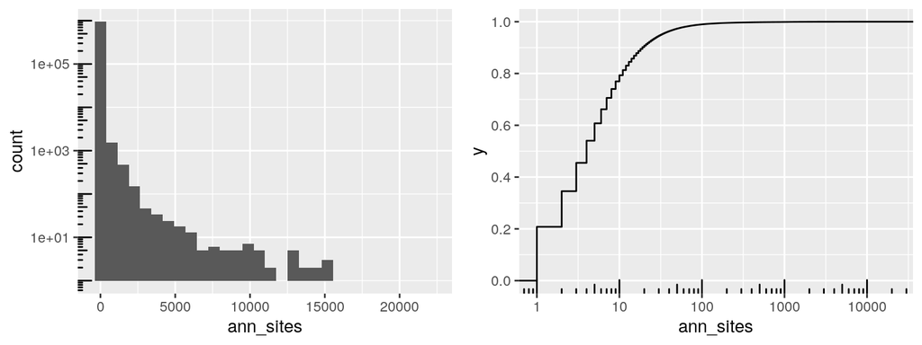

```r
plot_grid(
  ggplot(dataset3, aes(x=ann_sites)) +
    geom_histogram(bins=30) +
    scale_y_log10() +
    annotation_logticks(sides="l"),
  ggplot(dataset3, aes(x=ann_sites)) +
    stat_ecdf() +
    scale_x_log10() +
    scale_y_continuous(breaks=seq(0, 1, by=0.2)) +
    annotation_logticks(sides="b"))
```

# 4. Size, lines of code, and tokens

Size is in bytes. Lines of code ignores comments and lines that only contain whitespace. Token counts were estimated by running the SantaCoder tokenizer.

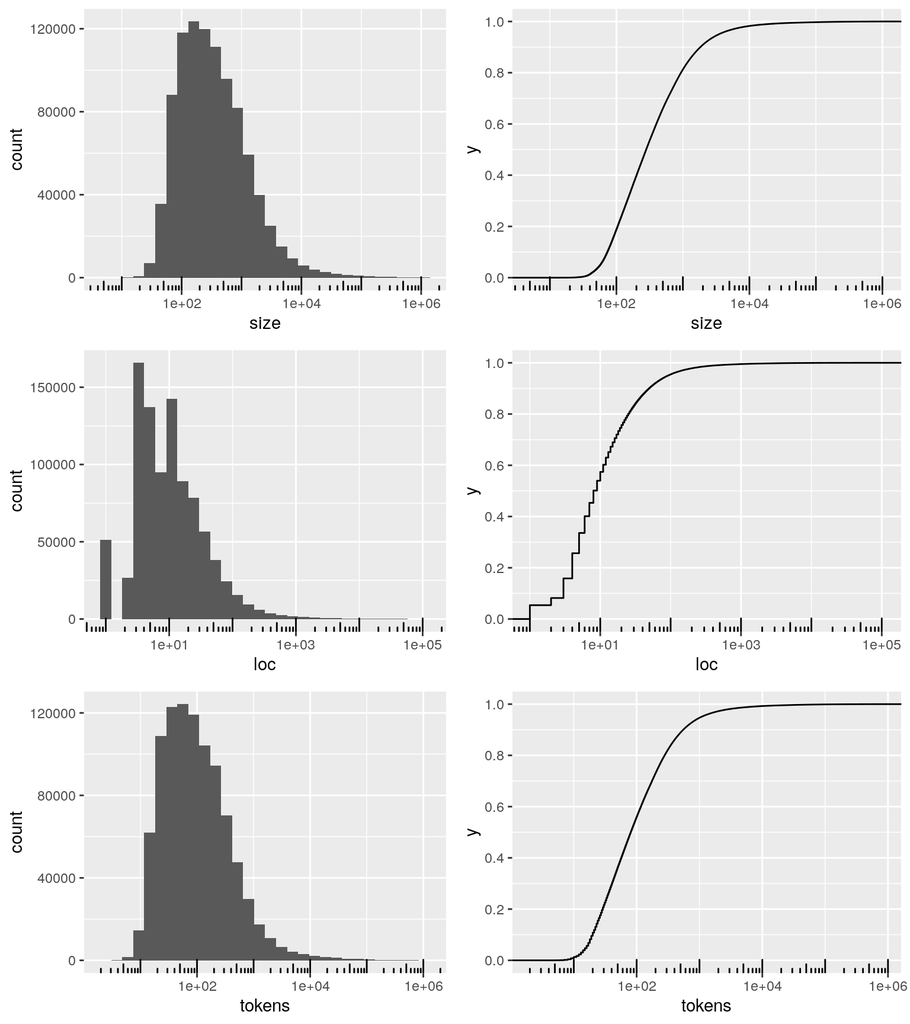

```r
plot_grid(
  ggplot(dataset3, aes(x=size)) +
    geom_histogram(bins=30) +
    scale_x_log10() +
    annotation_logticks(sides="b"),
  ggplot(dataset3, aes(x=size)) +
    stat_ecdf() +
    scale_x_log10() +
    scale_y_continuous(breaks=seq(0, 1, by=0.2)) +
    annotation_logticks(sides="b"),
  ggplot(dataset3, aes(x=loc)) +
    geom_histogram(bins=30) +
    scale_x_log10() +
    annotation_logticks(sides="b"),
  ggplot(dataset3, aes(x=loc)) +
    stat_ecdf() +
    scale_x_log10() +
    scale_y_continuous(breaks=seq(0, 1, by=0.2)) +
    annotation_logticks(sides="b"),
  ggplot(dataset3, aes(x=tokens)) +
    geom_histogram(bins=30) +
    scale_x_log10() +
    annotation_logticks(sides="b"),
  ggplot(dataset3, aes(x=tokens)) +
    stat_ecdf() +
    scale_x_log10() +
    scale_y_continuous(breaks=seq(0, 1, by=0.2)) +
    annotation_logticks(sides="b"),
  ncol=2)
```

## Filtering

We’d like to filter out files that are too small. We could use size (which is in bytes) or tokens, but those counts include comments. Lines of code (which excludes blanks and comments) might be a better measure of what a programmer actually writes, but lines of code have different lengths, and some programs put everything onto a single line.

Let’s start by looking at the single-line programs. (We’ll do this in the REPL since the output is too long to include in this notebook.)

```r
dataset3 %>% filter(loc == 1) %>% slice_max(size) %>% peek_sample(samples=1, truncate=FALSE)
dataset3 %>% filter(loc == 1) %>% slice_min(size, n=10) %>% peek_sample
dataset3 %>% filter(loc == 1) %>% slice_max(ann_sites) %>% peek_sample(samples=1, truncate=FALSE)
```

Looking at some of these files, we see files that are very large but meaningless (e.g., base64-encoded data), very small and meaningless, or declaring hundreds of variables but containing no other content. In other words, they do not appear to be useful, human-written programs.

```r
dataset3 %>% filter(loc < 50) %>% peek_sample
```

Looking at files with less than 50 lines of code, most of them are declarations with little functionality, or very small functions. Let’s use this as our cutoff for now.

```r
dataset4 <- dataset3 %>% filter(loc >= 50)
```

This removes 854307 files and leaves 94766.

# 5. Number of functions

Next, let’s look at the number of functions in each file.

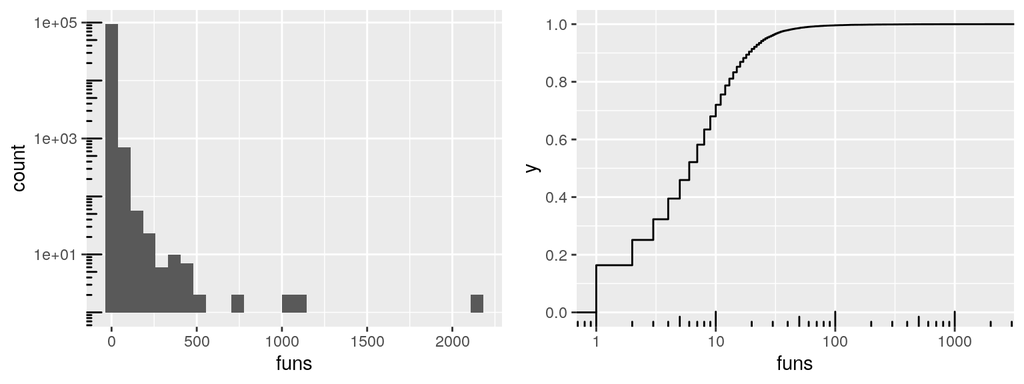

```r
plot_grid(
  ggplot(dataset4, aes(funs)) +
    geom_histogram(bins=30) +
    scale_y_log10() +
    annotation_logticks(sides="l"),
  ggplot(dataset4, aes(x=funs)) +
    stat_ecdf() +
    scale_x_log10() +
    scale_y_continuous(breaks=seq(0, 1, by=0.2)) +
    annotation_logticks(sides="b"))
```

## Filtering

We prefer having more functions, since that is code that is actually computing something, and therefore more interesting to type annotate (as opposed to type definitions, which may already be type annotated).

```r
dataset4 %>% filter(funs == 0) %>% slice_max(fun_params, n=10) %>% peek_sample(truncate=FALSE)
dataset4 %>% filter(funs == 0) %>% slice_max(var_decls, n=10) %>% peek_sample
dataset4 %>% filter(funs == 0) %>% slice_max(prop_decls, n=10) %>% peek_sample(truncate=FALSE)
```

We see that files with no functions are exporting functions (so there are function parameters but no function bodies), exporting constants, or declaring interfaces/classes.

Additionally, predicting types makes more sense when there is code that uses the types; a class/interface definition provides little information for property types, other than the property names.

Also, when predicting types for JavaScript, only modern JavaScript code (i.e. ES6) will have class definitions.

Therefore, we want files with function definitions. We’ll set our cutoff to 1 for now.

```r
dataset5 <- dataset4 %>% filter(funs > 0)
```

This removes 60951 files and leaves 33815.

# 6. Lines of code per function

We prefer functions with more lines of code, since those functions are more likely to be doing some computation (that involves types), instead of doing something simple such as getting/setting properties.

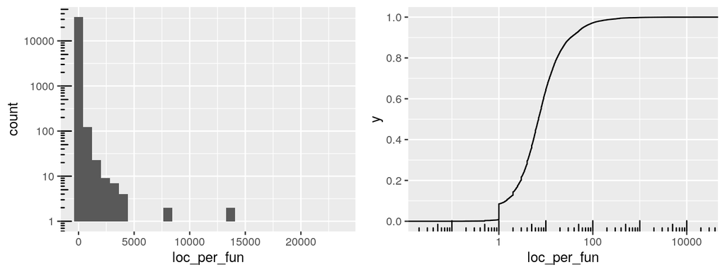

```r
plot_grid(
  ggplot(dataset5, aes(loc_per_fun)) +
    geom_histogram(bins=30) +
    scale_y_log10() +
    annotation_logticks(sides="l"),
  ggplot(dataset5, aes(x=loc_per_fun)) +
    stat_ecdf() +
    scale_x_log10() +
    scale_y_continuous(breaks=seq(0, 1, by=0.2)) +
    annotation_logticks(sides="b"))
```

## Filtering

Let’s peek at some of the files with the fewest and most lines of code per function.

```r
dataset5 %>% filter(loc_per_fun > 0) %>% slice_min(loc_per_fun, n=10) %>% peek_sample(truncate=FALSE)
dataset5 %>% filter(loc > 0 & loc_per_fun < 5) %>% peek_sample(truncate=FALSE)
dataset5 %>% filter(loc > 5 & loc_per_fun < 10) %>% peek_sample(truncate=FALSE)
dataset5 %>% slice_max(loc_per_fun, n=10) %>% peek_sample
```

There are many files with empty functions, so we should filter those out. We also see that the really large functions are returning large dictionaries and other constants. Hopefully we can mitigate this by preferring a higher annotation density.

```r
dataset6 <- dataset5 %>% filter(loc_per_fun >= 5)
```

This removes 12351 files and leaves 21464.

# 7. Combined metric

There are other criteria we can use to filter the dataset; however, they do not seem suitable as hard cutoffs. For now, we examine them, and will use them in a combined metric.

## Function usages

Are the functions defined within a file also used by that file? We prefer files where this is true, because our type prediction algorithm can take advantage of function usages and provide them as additional context to the type prediction model.

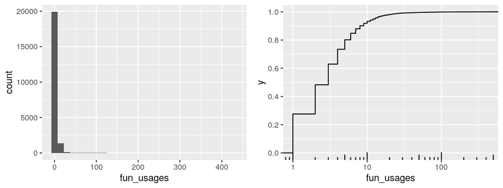

```r
plot_grid(
  ggplot(dataset6, aes(x=fun_usages)) +
    geom_histogram(bins=30),
  ggplot(dataset6, aes(x=fun_usages)) +
    stat_ecdf() +
    scale_x_log10() +
    scale_y_continuous(breaks=seq(0, 1, by=0.2)) +
    annotation_logticks(sides="b"))
```

```r
dataset6 %>% filter(fun_usages == 0) %>% peek_sample
dataset6 %>% filter(fun_usages == 0 & funs > 0) %>% peek_sample
```

At this point, all the files with at least one function usage also have at least one function definition. Therefore, for now, we do not set a cutoff for function usages.

## Type annotation density

Let’s return to type annotation sites. But now we want a measure of “density,” to avoid very large files with few annotations.

However, it will be more useful to separate the annotation sites into function annotations (including parameters and function returns), variable annotations, and property annotations, and compute three separate annotation densities. This is because we prefer certain annotation sites over others.

$$\begin{aligned}
\textrm{function annotation density} &= \frac{\textrm{functions +
parameters}}{\textrm{tokens}}
\\\\
\textrm{variable annotation density} &= \frac{\textrm{variable
declarations}}{\textrm{tokens}}
\\\\
\textrm{property annotation density} &= \frac{\textrm{property
declarations}}{\textrm{tokens}}
\end{aligned}$$

`loc` does not make sense as the denominator, because some programs are all on one line, so we could have density > 1. `tokens` seems to be more spread out than `size`, so we will use that as the denominator.

```r
dataset6 <- dataset6 %>%
  mutate(ann_density = ann_sites / tokens,
         fun_ann_density = (funs + fun_params) / tokens,
         var_ann_density = var_decls / tokens,
         prop_ann_density = prop_decls / tokens)
```

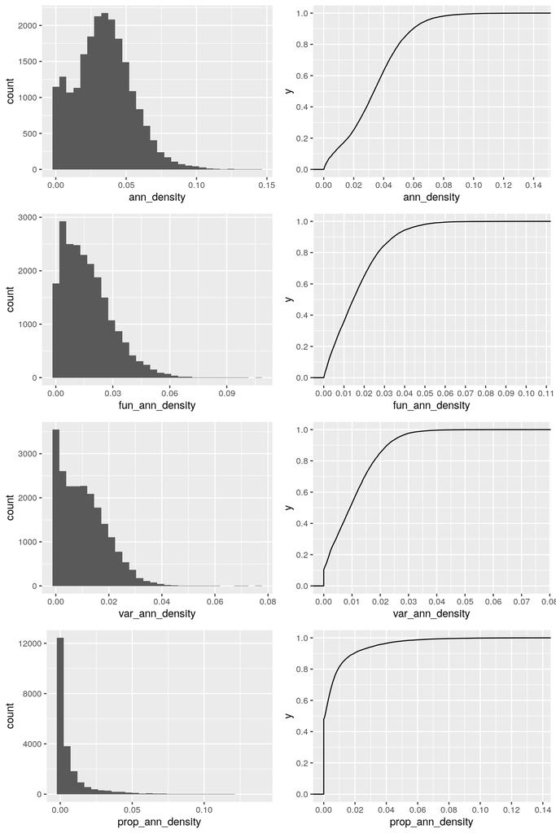

```r
plot_grid(
  ggplot(dataset6, aes(x=ann_density)) +
    geom_histogram(bins=30),
  ggplot(dataset6, aes(x=ann_density)) +
    stat_ecdf() +
    scale_x_continuous(breaks=scales::pretty_breaks(n=10)) +
    scale_y_continuous(breaks=seq(0, 1, by=0.2)),
  ggplot(dataset6, aes(x=fun_ann_density)) +
    geom_histogram(bins=30),
  ggplot(dataset6, aes(x=fun_ann_density)) +
    stat_ecdf() +
    scale_x_continuous(breaks=scales::pretty_breaks(n=10)) +
    scale_y_continuous(breaks=seq(0, 1, by=0.2)),
  ggplot(dataset6, aes(x=var_ann_density)) +
    geom_histogram(bins=30),
  ggplot(dataset6, aes(x=var_ann_density)) +
    stat_ecdf() +
    scale_x_continuous(breaks=scales::pretty_breaks(n=10)) +
    scale_y_continuous(breaks=seq(0, 1, by=0.2)),
  ggplot(dataset6, aes(x=prop_ann_density)) +
    geom_histogram(bins=30),
  ggplot(dataset6, aes(x=prop_ann_density)) +
    stat_ecdf() +
    scale_x_continuous(breaks=scales::pretty_breaks(n=10)) +
    scale_y_continuous(breaks=seq(0, 1, by=0.2)),
  ncol=2)
```

It’s not clear if we should set a cutoff for annotation density.

## Type definition density

A type definition is defined as a class definition, interface definition, or type alias. We prefer examples with more type definitions, because this suggests interesting, user-defined types, instead of builtin types. Furthermore, class and interface definitions have properties which can be type annotated.

```r
dataset6 <- dataset6 %>% mutate(typedef_density = type_defs / tokens)
```

We calculate the type definition density, using `tokens` as the denominator:

$$\textrm{type definition density} = \frac{\textrm{type
definitions}}{\textrm{tokens}}$$

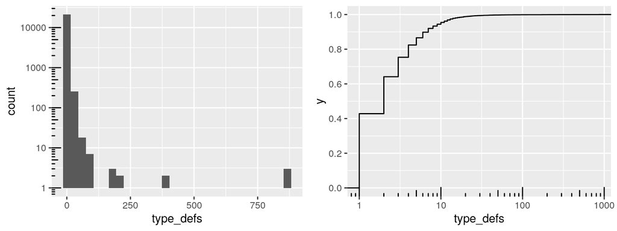

```r
plot_grid(
  ggplot(dataset6, aes(x=type_defs)) +
    geom_histogram(bins=30) +
    scale_y_log10() +
    annotation_logticks(sides="l"),
  ggplot(dataset6, aes(x=type_defs)) +
    stat_ecdf() +
    scale_x_log10() +
    scale_y_continuous(breaks=seq(0, 1, by=0.2)) +
    annotation_logticks(sides="b"))
```

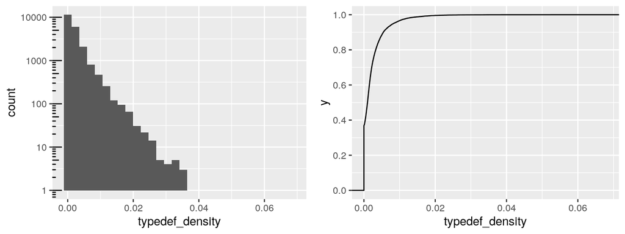

```r
plot_grid(
  ggplot(dataset6, aes(x=typedef_density)) +
    geom_histogram(bins=30) +
    scale_y_log10() +
    annotation_logticks(sides="l"),
  ggplot(dataset6, aes(x=typedef_density)) +
    stat_ecdf() +
    scale_y_continuous(breaks=seq(0, 1, by=0.2)))
```

It may be useful to prefer files with higher type definition density, but we don’t want to set a cutoff: many usable examples may have few (if any) type definitions.

## Dynamism

Certain constructs like `eval` make type inference challenging. Similarly, `instanceof` and `typeof` are escape hatches, though there are legitimate uses in TypeScript.

Let’s compute the “dynamism density”:

$$\textrm{dynamism density} = \frac{\textrm{dynamism}}{\textrm{tokens}}$$

```r
dataset6 <- dataset6 %>% mutate(dynamism_density = dynamism / tokens)
```

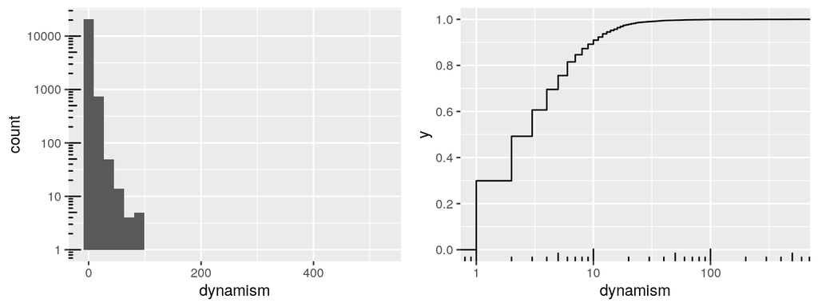

```r
plot_grid(
  ggplot(dataset6, aes(x=dynamism)) +
    geom_histogram(bins=30) +
    scale_y_log10() +
    annotation_logticks(sides = "l"),
  ggplot(dataset6, aes(x=dynamism)) +
    stat_ecdf() +
    scale_x_log10() +
    scale_y_continuous(breaks=seq(0, 1, by=0.2)) +
    annotation_logticks(sides="b"))
```

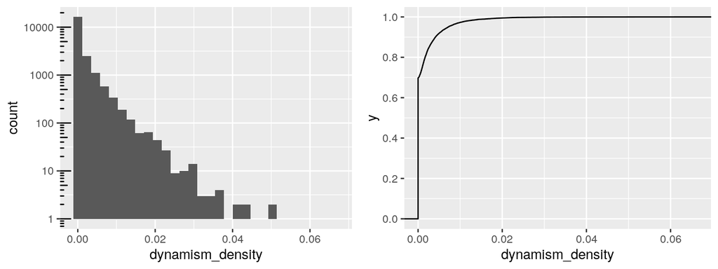

```r
plot_grid(
  ggplot(dataset6, aes(x=dynamism_density)) +
    geom_histogram(bins=30) +
    scale_y_log10() +
    annotation_logticks(sides="l"),
  ggplot(dataset6, aes(x=dynamism_density)) +
    stat_ecdf() +
    scale_y_continuous(breaks=seq(0, 1, by=0.2)))
```

It’s not clear if we should have a cutoff for dynamism density. We may prefer files with less dynamism, but there are many legitimate use cases.

## Trivial and predefined type density

A trivial type annotation is any occurrence of `any` or `Function`. This includes type arguments, e.g. `any[]` and `Array<any>` are counted as trivial types, and `MyType<any, any>` counts `any` twice.

A predefined type is any occurrence of `number`, `boolean`, `string`, `symbol`, `void`, `unknown`, `never`, or `object`. Like our definition for trivial types, this includes type arguments, so `MyType<number, string>` and `number | string` each count as two predefined types but only one annotation site. The motivation is that a file with mostly predefined types is less interesting than a file with user-defined types.

We calculate the trivial type density, using the number of annotation sites as the denominator. This is an approximation, because the type `MyType<any, any>` has two trivial types but counts for a single annotation site.

$$\textrm{trivial type density} = \frac{\textrm{trivial
types}}{\textrm{annotation sites}}$$

We calculate the predefined type density, using annotation sites as the denominator.

$$\textrm{predefined type density} = \frac{\textrm{predefined
types}}{\textrm{annotation sites}}$$

```r
dataset6 <- dataset6 %>% mutate(predefined_density = predefined_types / ann_sites,
                                trivial_density = trivial_types / ann_sites)
```

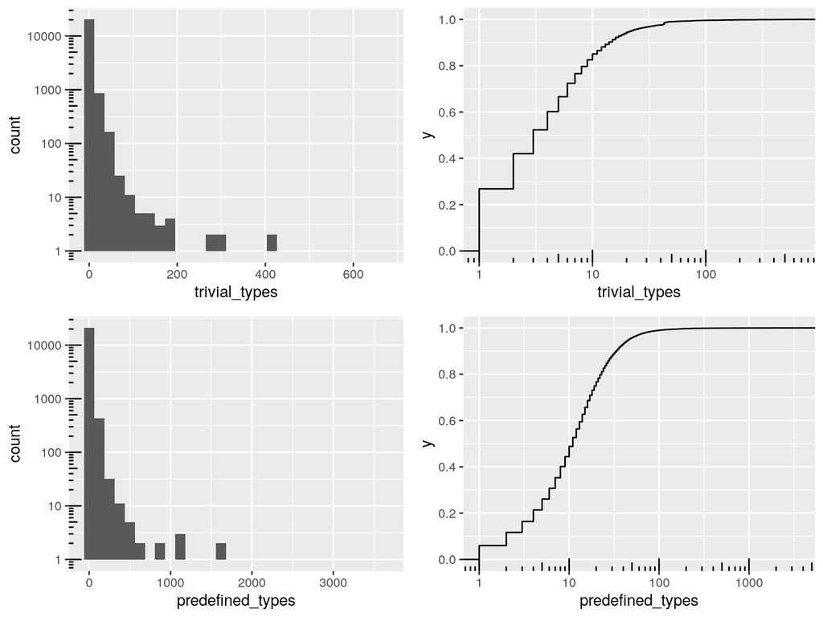

```r
plot_grid(
  ggplot(dataset6, aes(x=trivial_types)) +
    geom_histogram(bins=30) +
    scale_y_log10() +
    annotation_logticks(sides="l"),
  ggplot(dataset6, aes(x=trivial_types)) +
    stat_ecdf() +
    scale_x_log10() +
    scale_y_continuous(breaks=seq(0, 1, by=0.2)) +
    annotation_logticks(sides="b"),
  ggplot(dataset6, aes(x=predefined_types)) +
    geom_histogram(bins=30) +
    scale_y_log10() +
    annotation_logticks(sides="l"),
  ggplot(dataset6, aes(x=predefined_types)) +
    stat_ecdf() +
    scale_x_log10() +
    scale_y_continuous(breaks=seq(0, 1, by=0.2)) +
    annotation_logticks(sides="b"))
```

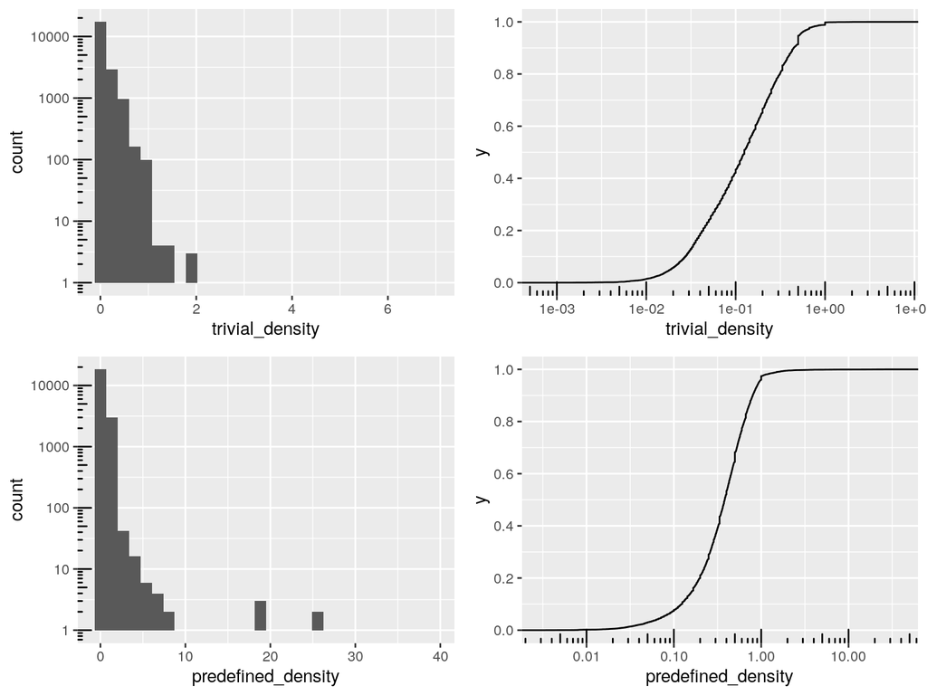

```r
plot_grid(
  ggplot(dataset6, aes(x=trivial_density)) +
    geom_histogram(bins=30) +
    scale_y_log10() +
    annotation_logticks(sides="l"),
  ggplot(dataset6, aes(x=trivial_density)) +
    stat_ecdf() +
    scale_x_log10() +
    scale_y_continuous(breaks=seq(0, 1, by=0.2)) +
    annotation_logticks(sides="b"),
  ggplot(dataset6, aes(x=predefined_density)) +
    geom_histogram(bins=30) +
    scale_y_log10() +
    annotation_logticks(sides="l"),
  ggplot(dataset6, aes(x=predefined_density)) +
    stat_ecdf() +
    scale_x_log10() +
    scale_y_continuous(breaks=seq(0, 1, by=0.2)) +
    annotation_logticks(sides="b"))
```

## Defining the combined metric

So far, we have looked at individual metrics, and used some of them as cutoffs to filter out low-quality examples.

However, there are certain metrics we would like to optimize and not use as cutoffs:

- Higher {function,variable,property} annotation density
- Higher type definition density
- Lower dynamism density
- Lower {trivial,predefined} type density
- Higher lines of code per function
- Higher function usages

To do so we will compute z-scores for each metric, which indicate how many standard deviations above or below the mean. We negate the scores that we want to minimize.

```r
add_zscores <- function(dataset) {
  dataset %>%
    mutate(z.fun_ann_density = zscore(fun_ann_density),
           z.var_ann_density = zscore(var_ann_density),
           z.prop_ann_density = zscore(prop_ann_density),
           z.typedef_density = zscore(typedef_density),
           z.dynamism_density = -zscore(dynamism_density),
           z.trivial_density = -zscore(trivial_density),
           z.predefined_density = -zscore(predefined_density),
           z.loc_per_fun = zscore(loc_per_fun),
           z.fun_usages = zscore(fun_usages))
}
```

Next we normalize the scores.

```r
add_normalized <- function(dataset) {
  dataset %>%
    mutate(m.fun_ann_density = normalize(z.fun_ann_density),
           m.var_ann_density = normalize(z.var_ann_density),
           m.prop_ann_density = normalize(z.prop_ann_density),
           m.typedef_density = normalize(z.typedef_density),
           m.dynamism_density = normalize(z.dynamism_density),
           m.trivial_density = normalize(z.trivial_density),
           m.predefined_density = normalize(z.predefined_density),
           m.loc_per_fun = normalize(z.loc_per_fun),
           m.fun_usages = normalize(z.fun_usages))
}
```

Finally, we compute a weighted sum of the metrics.

- The most important factors are function and variable annotation density: we want files with functions and variables to annotate.
- Higher property annotation density is generally good, but we are less interested in type annotating properties. Furthermore, to avoid double counting (since type definition density is another metric, and type definitions are correlated with properties), we weight property annotation density to 0.
- Type definition density is useful to have more interesting types, but too much weight on this metric means files that are only declaring types and don’t have functions.
- Dynamism density has very little weight, as it is generally uncommon.
- Trivial type density and predefined type density are not as important, but trivial types are “worse” than predefined types so it should have more weight.
- We prefer files with larger functions, but not to the extent where a single function can dominate the entire file.
- We also prefer more function usages.

```r
add_weighted_score <- function(dataset) {
  w.fun_ann_density <- 25
  w.var_ann_density <- 25
  w.prop_ann_density <- 0
  w.typedef_density <- 11
  w.dynamism_density <- 1
  w.trivial_density <- 11
  w.predefined_density <- 5
  w.loc_per_fun <- 11
  w.fun_usages <- 11

  w.sum <- w.fun_ann_density +
    w.var_ann_density +
    w.prop_ann_density +
    w.typedef_density +
    w.dynamism_density +
    w.trivial_density +
    w.predefined_density +
    w.loc_per_fun +
    w.fun_usages

  dataset %>%
    mutate(metric = (
      w.fun_ann_density * m.fun_ann_density +
      w.var_ann_density * m.var_ann_density +
      w.prop_ann_density * m.prop_ann_density +
      w.typedef_density * m.typedef_density +
      w.dynamism_density * m.dynamism_density +
      w.trivial_density * m.trivial_density +
      w.predefined_density * m.predefined_density +
      w.loc_per_fun * m.loc_per_fun +
      w.fun_usages * m.fun_usages)
    / w.sum)
}
```

Now that we’ve defined our functions (to avoid polluting the global namespace), we can run them on our dataset.

```r
dataset6 <- dataset6 %>% add_zscores %>% add_normalized %>% add_weighted_score
```

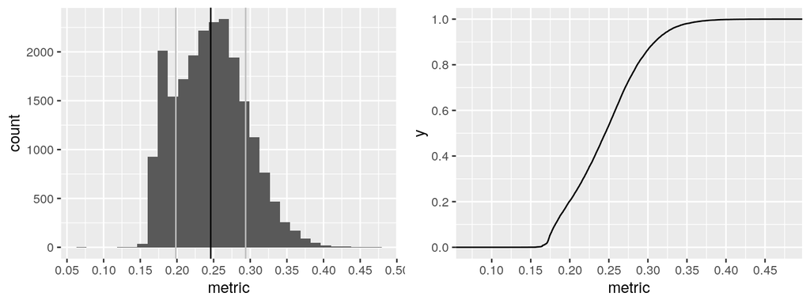

```r
plot_grid(
  ggplot(dataset6, aes(x=metric)) +
    geom_histogram(bins=30) +
    geom_vline(aes(xintercept=mean(metric)), color="black") +
    geom_vline(aes(xintercept=mean(metric)-sd(metric)), color="grey") +
    geom_vline(aes(xintercept=mean(metric)+sd(metric)), color="grey") +
    scale_x_continuous(breaks=scales::pretty_breaks(n=10)),
  ggplot(dataset6, aes(x=metric)) +
    stat_ecdf() +
    scale_x_continuous(breaks=scales::pretty_breaks(n=10)) +
    scale_y_continuous(breaks=seq(0, 1, by=0.2)))
```

## Filtering

```r
dataset6 %>% slice_max(metric, n=10) %>% peek_sample()
dataset6 %>% slice_min(metric, n=10) %>% peek_sample()

metric_cutoff <- mean(dataset6$metric) - sd(dataset6$metric)
dataset6 %>% filter(metric < metric_cutoff) %>% slice_max(metric, n=10) %>% peek_sample()
```

The files with the lowest metric are uninteresting. Some are long and only return large data structures, some only define types and enums, and some use a lot of dynamism.

Next we look at the files with metrics more than 1 standard deviation below the mean; specifically we look at the ones with the highest metric, i.e. the ones that just barely got cut off. Most of these files are not very interesting, so we use -1 std.dev. (0.1984686) as our cutoff.

```r
metric_cutoff <- mean(dataset6$metric) - sd(dataset6$metric)
dataset7 <- dataset6 %>% filter(metric >= metric_cutoff)
```

This removes 4210 files and leaves 17254.

# Summary of filtering steps

1. Start with The Stack: 12,817,789
2. Filter for files that are self-contained (no `import`/`export`/`require`) and type check: 1,141,871
3. Filter `ann_sites > 0`: 949,073
4. Filter `loc >= 50`: 94,766
5. Filter `funs > 0`: 33,815
6. Filter `loc_per_fun >= 5`: 21,464
7. Filter `metric >= mean(metric) - sd(metric)`: 17,254
8. Filter after 2021-12-31 cutoff: 867
9. Remove type annotations: 744

The metric is a weighted sum of the following factors:

| Factor | Weight |
| --- | --- |
| function annotation density | 25% |
| variable annotation density | 25% |
| type definition density | 11% |
| dynamism density | 1% |
| trivial types density | 11% |
| predefined types density | 5% |
| lines of code per function | 11% |
| number of function usages | 11% |

# Write dataset

```r
write_dataset <- function(dataset) {
  original <- read_parquet("../../../datasets/ts-dataset-full.parquet",
                         as_data_frame=TRUE) %>% as_tibble
  hexsha <- dataset %>% select(hexsha)
  output <- right_join(original, hexsha, by="hexsha")
  write_parquet(output, "../../../datasets/ts-dataset-filtered-r.parquet")
}
write_dataset(dataset7)
```

Note: this dataset is written to disk for reference; the actual filtering is re-done in a Python script. That script does two further steps (#8 and #9 in the summary below). “Remove type annotations” also filters out files where removing the type annotations doesn’t make sense, e.g. index signatures.

# Exploring the evaluation dataset

```r
dataset9 <- read_parquet("../../../datasets/ts-eval.parquet",
                         as_data_frame=TRUE) %>%
  as_tibble %>%
  mutate(tokens = estimated_tokens, repo_path = max_stars_repo_path,
         repo_name = max_stars_repo_name, funs = functions,
         fun_sigs = function_signatures, fun_params = function_parameters,
         var_decls = variable_declarations, prop_decls = property_declarations,
         fun_usages = function_usages, trivial_types, predefined_types,
         type_defs = type_definitions, dynamism = dynamism_heuristic,
         loc_per_fun = loc_per_function)
```

## Annotation sites

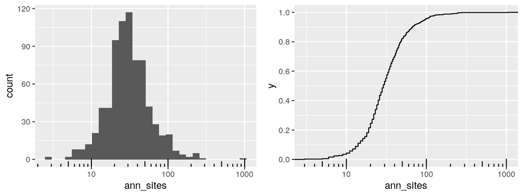

```r
plot_grid(
  ggplot(dataset9, aes(x=funs + fun_sigs + fun_params + var_decls + prop_decls)) +
    geom_histogram(bins=30) +
    xlab("ann_sites") +
    scale_x_log10() +
    annotation_logticks(sides="b"),
  ggplot(dataset9, aes(x=funs + fun_sigs + fun_params + var_decls + prop_decls)) +
    stat_ecdf() +
    scale_x_log10() +
    xlab("ann_sites") +
    scale_y_continuous(breaks=seq(0, 1, by=0.2)) +
    annotation_logticks(sides="b"))
```

## Lines of code and tokens

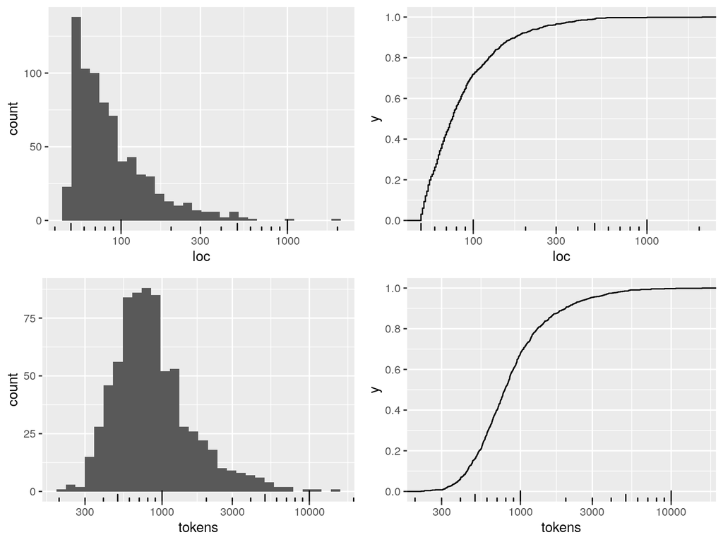

```r
plot_grid(
  ggplot(dataset9, aes(x=loc)) +
    geom_histogram(bins=30) +
    scale_x_log10() +
    annotation_logticks(sides="b"),
  ggplot(dataset9, aes(x=loc)) +
    stat_ecdf() +
    scale_x_log10() +
    scale_y_continuous(breaks=seq(0, 1, by=0.2)) +
    annotation_logticks(sides="b"),
  ggplot(dataset9, aes(x=tokens)) +
    geom_histogram(bins=30) +
    scale_x_log10() +
    annotation_logticks(sides="b"),
  ggplot(dataset9, aes(x=tokens)) +
    stat_ecdf() +
    scale_x_log10() +
    scale_y_continuous(breaks=seq(0, 1, by=0.2)) +
    annotation_logticks(sides="b"),
  ncol=2)
```

## Functions

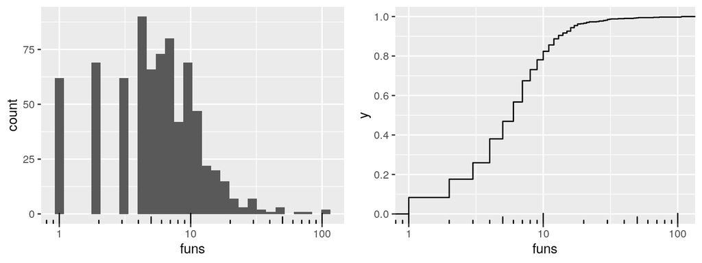

```r
plot_grid(
  ggplot(dataset9, aes(funs)) +
    geom_histogram(bins=30) +
    scale_x_log10() +
    annotation_logticks(sides="b"),
  ggplot(dataset9, aes(x=funs)) +
    stat_ecdf() +
    scale_x_log10() +
    scale_y_continuous(breaks=seq(0, 1, by=0.2)) +
    annotation_logticks(sides="b"))
```

## Lines of code per function

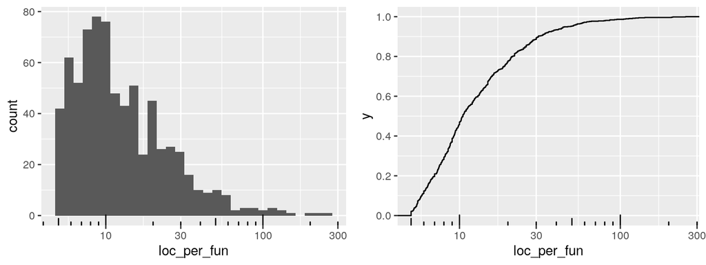

```r
plot_grid(
  ggplot(dataset9, aes(loc_per_fun)) +
    geom_histogram(bins=30) +
    scale_x_log10() +
    annotation_logticks(sides="b"),
  ggplot(dataset9, aes(x=loc_per_fun)) +
    stat_ecdf() +
    scale_x_log10() +
    scale_y_continuous(breaks=seq(0, 1, by=0.2)) +
    annotation_logticks(sides="b"))
```

## Function usages

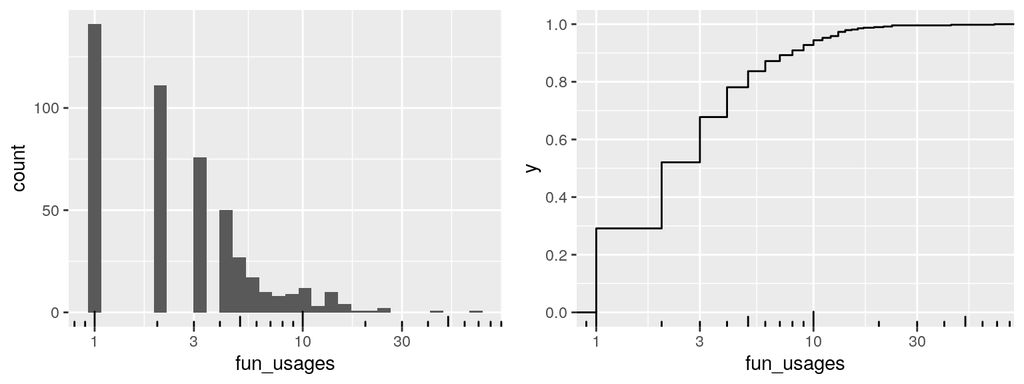

```r
plot_grid(
  ggplot(dataset9, aes(x=fun_usages)) +
    geom_histogram(bins=30) +
    scale_x_log10() +
    annotation_logticks(sides="b"),
  ggplot(dataset9, aes(x=fun_usages)) +
    stat_ecdf() +
    scale_x_log10() +
    scale_y_continuous(breaks=seq(0, 1, by=0.2)) +
    annotation_logticks(sides="b"))
```

## Type annotation density

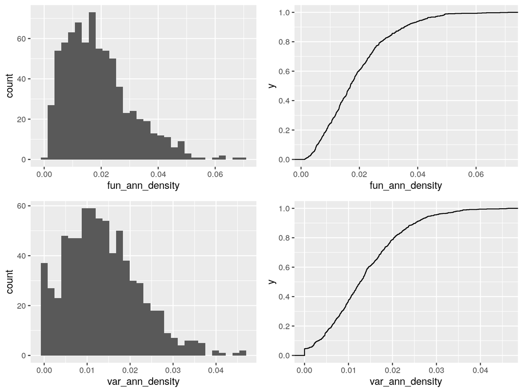

```r
plot_grid(
  ggplot(dataset9, aes(x=fun_ann_density)) +
    geom_histogram(bins=30),
  ggplot(dataset9, aes(x=fun_ann_density)) +
    stat_ecdf() +
    scale_y_continuous(breaks=seq(0, 1, by=0.2)),
  ggplot(dataset9, aes(x=var_ann_density)) +
    geom_histogram(bins=30),
  ggplot(dataset9, aes(x=var_ann_density)) +
    stat_ecdf() +
    scale_y_continuous(breaks=seq(0, 1, by=0.2)),
  ncol=2)
```

## Type definition density

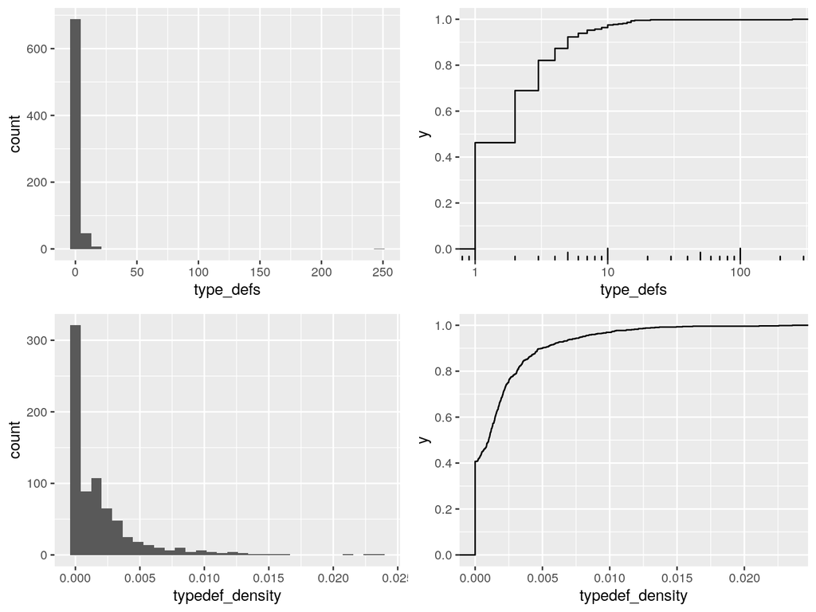

```r
plot_grid(
  ggplot(dataset9, aes(x=type_defs)) +
    geom_histogram(bins=30),
  ggplot(dataset9, aes(x=type_defs)) +
    stat_ecdf() +
    scale_x_log10() +
    scale_y_continuous(breaks=seq(0, 1, by=0.2)) +
    annotation_logticks(sides="b"),
  ggplot(dataset9, aes(x=typedef_density)) +
    geom_histogram(bins=30),
  ggplot(dataset9, aes(x=typedef_density)) +
    stat_ecdf() +
    scale_y_continuous(breaks=seq(0, 1, by=0.2)),
  ncol=2)
```

## Dynamism density

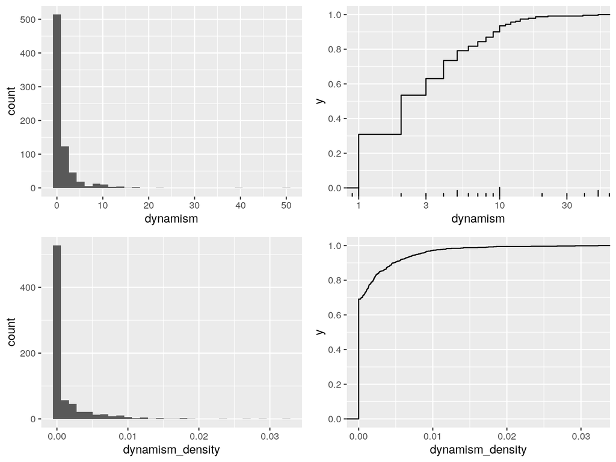

```r
plot_grid(
  ggplot(dataset9, aes(x=dynamism)) +
    geom_histogram(bins=30),
  ggplot(dataset9, aes(x=dynamism)) +
    stat_ecdf() +
    scale_x_log10() +
    scale_y_continuous(breaks=seq(0, 1, by=0.2)) +
    annotation_logticks(sides="b"),
  ggplot(dataset9, aes(x=dynamism_density)) +
    geom_histogram(bins=30),
  ggplot(dataset9, aes(x=dynamism_density)) +
    stat_ecdf() +
    scale_y_continuous(breaks=seq(0, 1, by=0.2)),
  ncol=2)
```

## Trivial and predefined types density

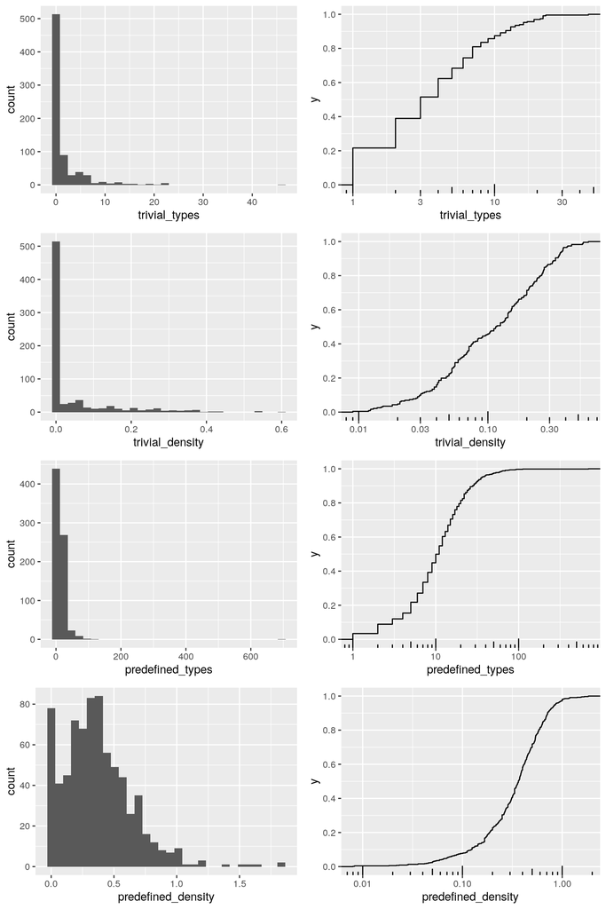

```r
plot_grid(
  ggplot(dataset9, aes(x=trivial_types)) +
    geom_histogram(bins=30),
  ggplot(dataset9, aes(x=trivial_types)) +
    stat_ecdf() +
    scale_x_log10() +
    scale_y_continuous(breaks=seq(0, 1, by=0.2)) +
    annotation_logticks(sides="b"),
  ggplot(dataset9, aes(x=trivial_density)) +
    geom_histogram(bins=30),
  ggplot(dataset9, aes(x=trivial_density)) +
    stat_ecdf() +
    scale_x_log10() +
    scale_y_continuous(breaks=seq(0, 1, by=0.2)) +
    annotation_logticks(sides="b"),
  ggplot(dataset9, aes(x=predefined_types)) +
    geom_histogram(bins=30),
  ggplot(dataset9, aes(x=predefined_types)) +
    stat_ecdf() +
    scale_x_log10() +
    scale_y_continuous(breaks=seq(0, 1, by=0.2)) +
    annotation_logticks(sides="b"),
  ggplot(dataset9, aes(x=predefined_density)) +
    geom_histogram(bins=30),
  ggplot(dataset9, aes(x=predefined_density)) +
    stat_ecdf() +
    scale_x_log10() +
    scale_y_continuous(breaks=seq(0, 1, by=0.2)) +
    annotation_logticks(sides="b"),
  ncol=2)
```